# Tarea 04: Visualización preliminar de datos

Ana Paola Arias, Alejandro Gutiérrez, Sofía Palacios Cuevas,

23/9/2021

En esta actividad realizamos, mediante gráficos sencillos, una visualización preliminar de cada una de nuestras variables de interés.

**Nota al profesor:** Nos dimos cuenta de que eran demasiadas variables para trabajar, al tiempo que parece más útil para nuestros fines la base de datos por módulo. Por ello, pedimos la posibilidad de modificar el proyecto, de modo que sólo utilicemos dicha base. Finalmente, se intentó graficar a modo de columnas agrupadas, pero fue difícil redactar los comandos; por lo printo, reglizamos gráficas de barras. De lo anterior, cabe mencionar que en el código se pidió ver las categorías lado a lado (dodge), pero las arrogó encimadas (stack).

*Sugerencias para próxima entrega*

Columnas agrupadas

https://www.r-graph-gallery.com/48-grouped-barplot-with-ggplot2.html

# **Variables relacionadas con la vivienda**

Vamos a limpiar una de las bases de datos que utilizaremos. Para ello nos vamos a deshacer de las columnas que no necesitamos para el análisis de datos.

```r
# Llamamos a nuestras librerías
library(ggplot2)
library(viridisLite)
library(hrbrthemes)
# Leemos la base de datos original y aplicamos los pasos del primer parcial
# para curar la base
bd.original.vivienda<-read.csv("conjunto_de_datos_tvivienda_ecovid_ed_2020.csv")
bd.vivienda<-bd.original.vivienda[ ,-c(2,3,4,5,6,7,8,9,10,11,12,13,
                                         14,15,16,17,18,19,20,21,22,23,24,25,
                                         26,27,28,29, 64)]
# lo guardamos como csv para futuros trabajos
write.csv(bd.vivienda, "bd.vivienda.csv")

# Seleccionamos "bd.vivienda.csv" de Files e importamos
# Leemos y vemos la bd
bd.vivienda<-read.csv("bd.vivienda.csv")
View(bd.vivienda)
```

# **TICs**

### **Dispositivos con los que cuentan en su vivienda por entidad federativa**

## **Computadora de escritorio**

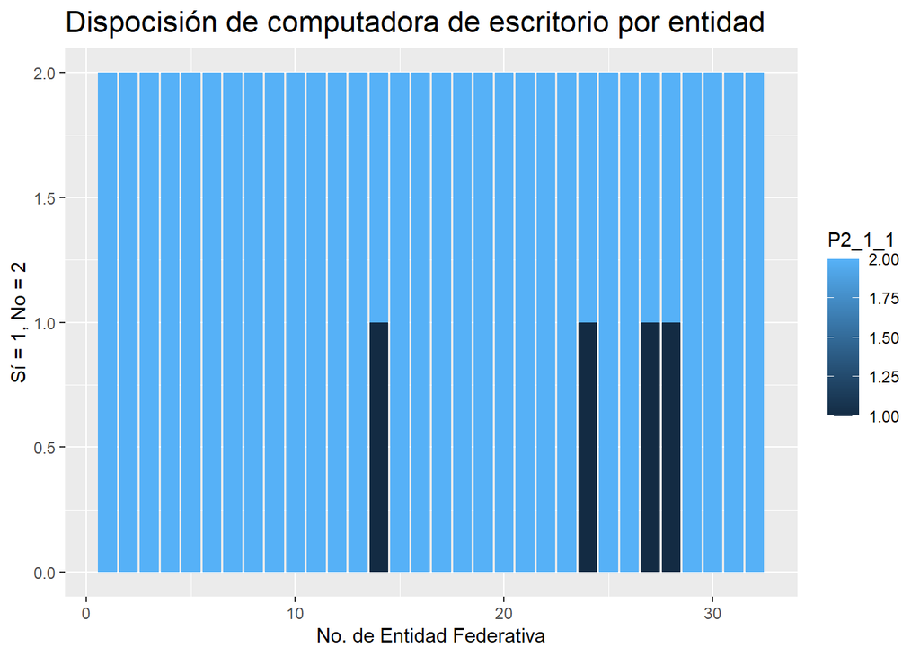

```r
# Hacemos nuestra primera gráfica (repetiremos este proceso en cada apartado)
ce<-ggplot(bd.vivienda, aes(x=ENT, y=P2_1_1, fill=P2_1_1)) +
  geom_bar(position="dodge",stat = "identity" ) +
  xlab("No. de Entidad Federativa") +
  ylab("Sí = 1, No = 2") +
  ggtitle("Dispocisión de computadora de escritorio por entidad" ) +
  theme(plot.title = element_text(size=16))
ce
```

## **Computadora portátil**

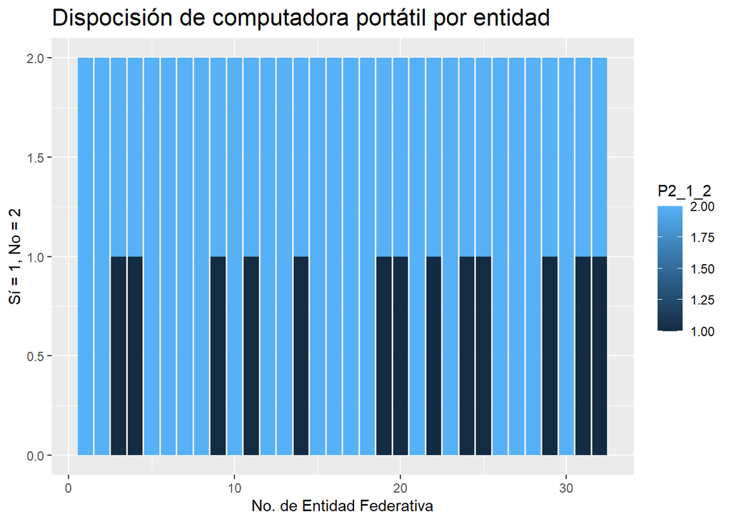

```r
# Graficamos
cp<-ggplot(bd.vivienda, aes(x=ENT, y=P2_1_2, fill=P2_1_2)) +
  geom_bar(position="dodge",stat = "identity" ) +
  xlab("No. de Entidad Federativa") +
  ylab("Sí = 1, No = 2") +
  ggtitle("Dispocisión de computadora portátil por entidad" ) +
  theme(plot.title = element_text(size=16))
cp
```

## **Televisión digital**

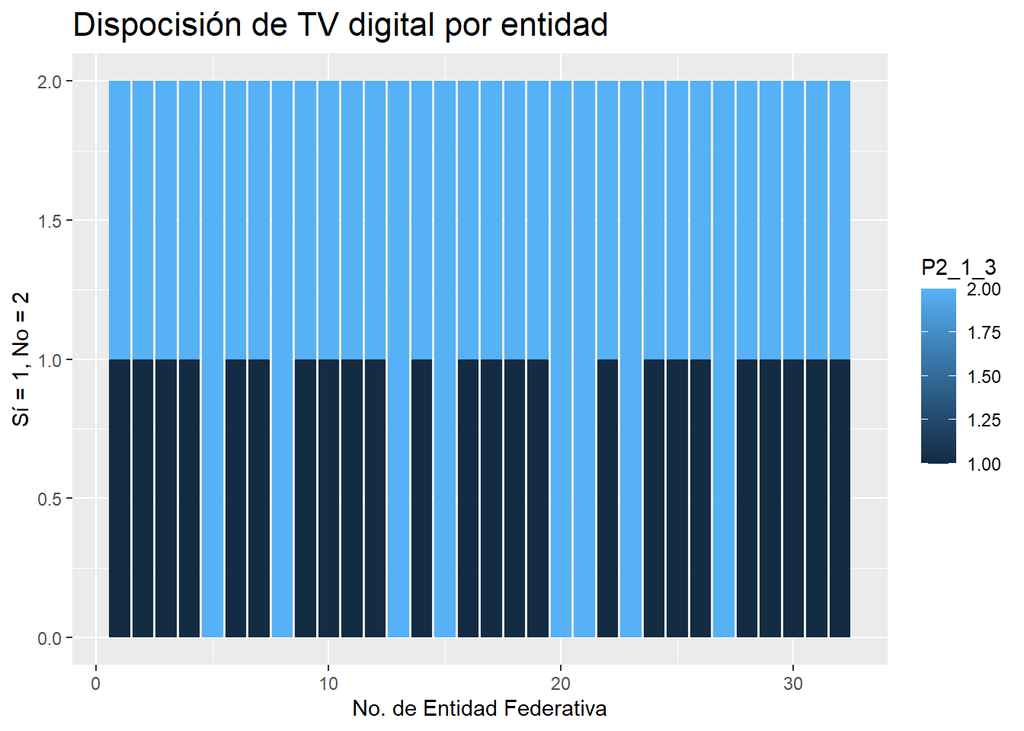

```r
# Graficamos
tv<-ggplot(bd.vivienda, aes(x=ENT, y=P2_1_3, fill=P2_1_3)) +
  geom_bar(position="dodge",stat = "identity" ) +
  xlab("No. de Entidad Federativa") +
  ylab("Sí = 1, No = 2") +
  ggtitle("Dispocisión de TV digital por entidad" ) +
  theme(plot.title = element_text(size=16))
tv
```

En esta gráfica se registra la disposición de TV digital por entidad. Podemos ver que la disposición de este dispositivo es mayor que la de la computadora portátil y la de escritorio, ya que en unicamente 8 estados se registraron casos negativos: Coahuila, Chihuahua, Hidalgo, Estadod e México, Oaxaca, Puebla, Quintana Roo y Tabasco.

## **Tablet**

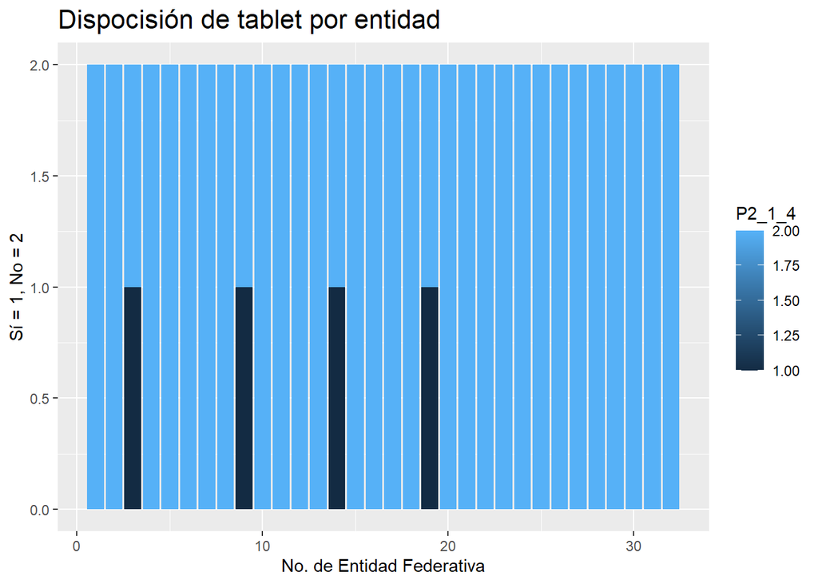

```r
# Graficamos
t<-ggplot(bd.vivienda, aes(x=ENT, y=P2_1_4, fill=P2_1_4)) +
  geom_bar(position="dodge",stat = "identity" ) +
  xlab("No. de Entidad Federativa") +
  ylab("Sí = 1, No = 2") +
  ggtitle("Dispocisión de tablet por entidad" ) +
  theme(plot.title = element_text(size=16))
t
```

En esta gráfica se muestra la disposición de tablet por entidad. Vemos que la mayoría de los estados contestaron que ‘’no’’, a excepción de Baja California Sur, Ciudad de México, Jalisco y Nuevo León.

## **Celular inteligente**

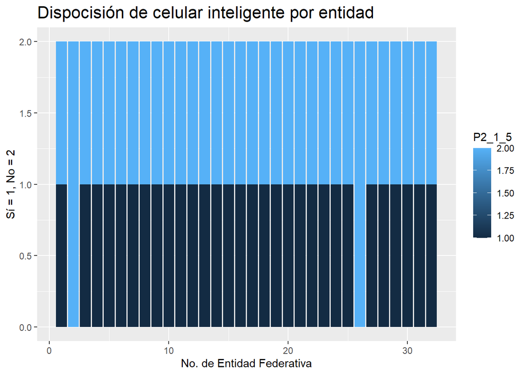

```r
# Graficamos
ci<-ggplot(bd.vivienda, aes(x=ENT, y=P2_1_5, fill=P2_1_5)) +
  geom_bar(position="dodge",stat = "identity" ) +
  xlab("No. de Entidad Federativa") +
  ylab("Sí = 1, No = 2") +
  ggtitle("Dispocisión de celular inteligente por entidad" ) +
  theme(plot.title = element_text(size=16))
ci
```

## **Conexión a Internet fijo**

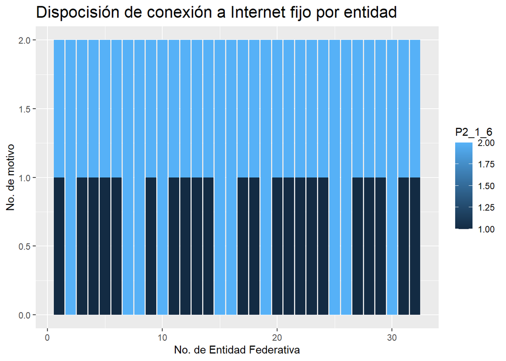

```r
# Graficamos
cif<-ggplot(bd.vivienda, aes(x=ENT, y=P2_1_6, fill=P2_1_6)) +
  geom_bar(position="dodge",stat = "identity" ) +
  xlab("No. de Entidad Federativa") +
  ylab("No. de motivo") +
  ggtitle("Dispocisión de conexión a Internet fijo por entidad" ) +
  theme(plot.title = element_text(size=16))
cif
```

En esta gráfica se meustra la disposiciónn de internet fijo por entidad. En esta ocasi´´on notamos que 10 estadospresentaron una mayoría de respuestas negativas.

# **Carencia de Internet fijo**

### **Motivos por entidad federativa**

```r
# Graficamos
m.cif<-ggplot(bd.vivienda, aes(x=ENT, y=P2_2, fill=P2_2)) +
  geom_bar(position="dodge",stat = "identity" ) +
  xlab("No. de Entidad Federativa") +
  ylab("No. de motivo") +
  ylim(0,6)+
  ggtitle("Motivos de carencia de Internet fijo por entidad federativa" ) +
  theme_ipsum()
  theme(plot.title = element_text(size=14))
```

[output not shown]

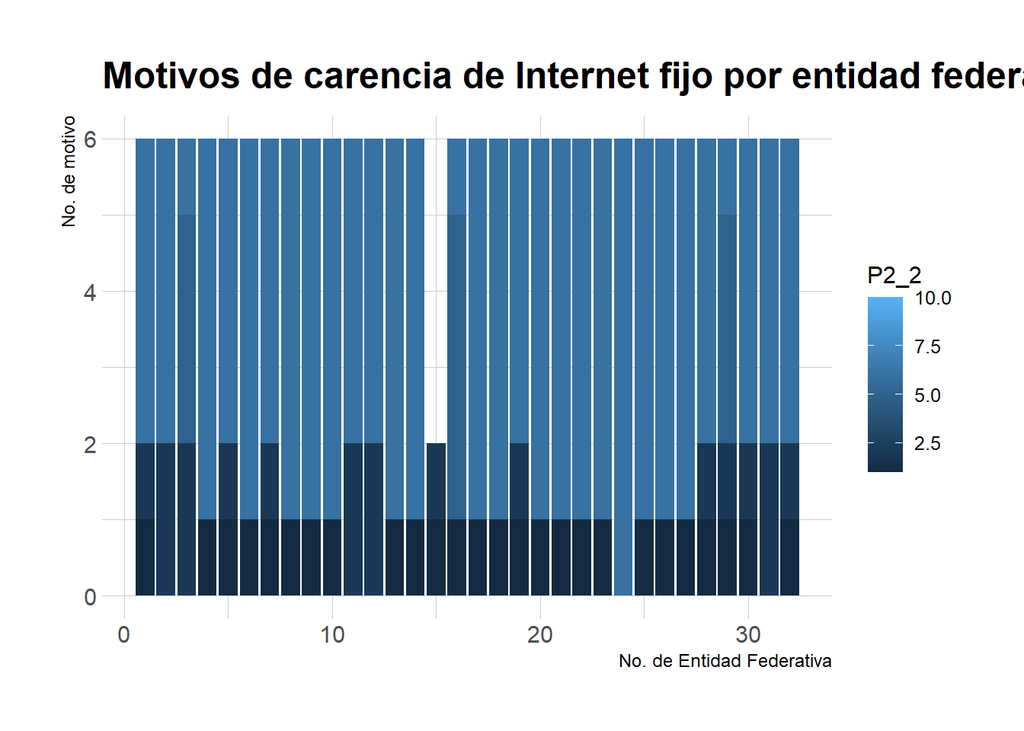

```r
m.cif
```

En esta gráfica se presentan los motivos de carencia por entidad federativa. Por el tipo de dato es dificil dar una interpetación de primera mano de este histograma.

## **Gastos inesperados para atender las clases por entidad federativa**

### **Internet fijo**

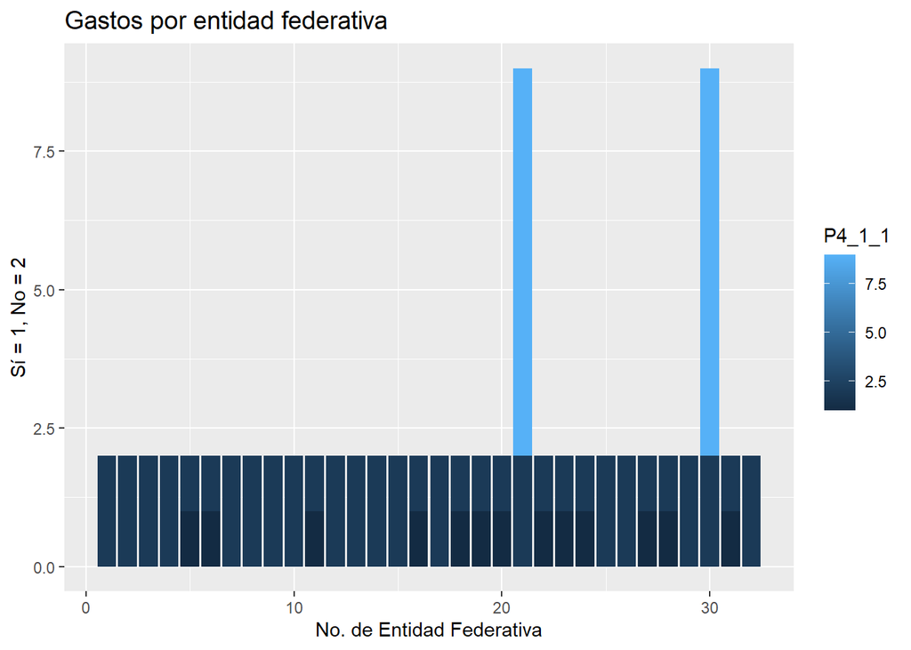

```r
# Graficamos
g.if<-ggplot(bd.vivienda, aes(x=ENT, y=P4_1_1, fill=P4_1_1)) +
  geom_bar(position="dodge",stat = "identity" ) +
  xlab("No. de Entidad Federativa") +
  ylab("Sí = 1, No = 2") +
  ggtitle("Gastos por entidad federativa" ) +
  theme(plot.title = element_text(size=14))
# La razón por la que salen esas dos barras largas es por los elementos NA,
# tenemos que ver cómo eliminarlos o cómo considerarlos un factor = 3
g.if
```

En esta grafica se presentan las respuestas a la pregunta sobre si se han tenido gastos adicionales que tengan que ver con la adquisición de equipo para las clases en línea.

# Variables relacionadas con el módulo de aprendizaje

```r
# Cargamos nuestras librerías
library(ggplot2)
library(viridisLite)
library(hrbrthemes)
# Leemos la base original y la curamos
bd.original.modulo<-read.csv("conjunto_de_datos_tmodulo_ecovid_ed_2020.csv")
bd.modulo<-bd.original.modulo[ ,-c(2,3,4,73)]
write.csv(bd.modulo, "bd.modulo.csv")
# Seleccionamos "bd.modulo.csv" de Files e importamos

# Leemos y vemos la bd
bd.modulo<-read.csv("bd.modulo.csv")
View(bd.modulo)
```

## Razones para no concluir el ciclo escolar pasado

### Por COVID 19

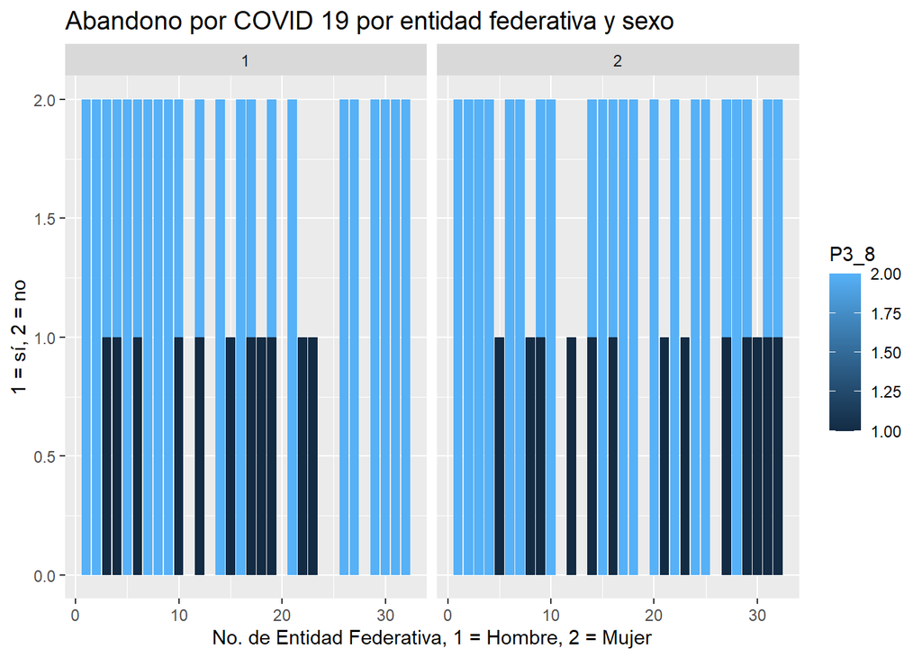

```r
# Cargamos las librerías
library(ggplot2)
library(viridisLite)
library(hrbrthemes)

# Graficamos
g1<-ggplot(bd.modulo, aes(x=ENT, y=P3_8, fill=P3_8)) +
  geom_bar(position="dodge",stat = "identity" ) +
  facet_wrap(~SEXO) +
  xlab("No. de Entidad Federativa, 1 = Hombre, 2 = Mujer") +
  ylab("1 = sí, 2 = no") +
  ggtitle("Abandono por COVID 19 por entidad federativa y sexo" ) +
  theme(plot.title = element_text(size=14))
g1
```

En esta gráfica se muestran las razones para no conluir los estudios durante la pandemia por COVID 19. Iremos revisando los resultados variable por variable.

### Por carencia de TICs

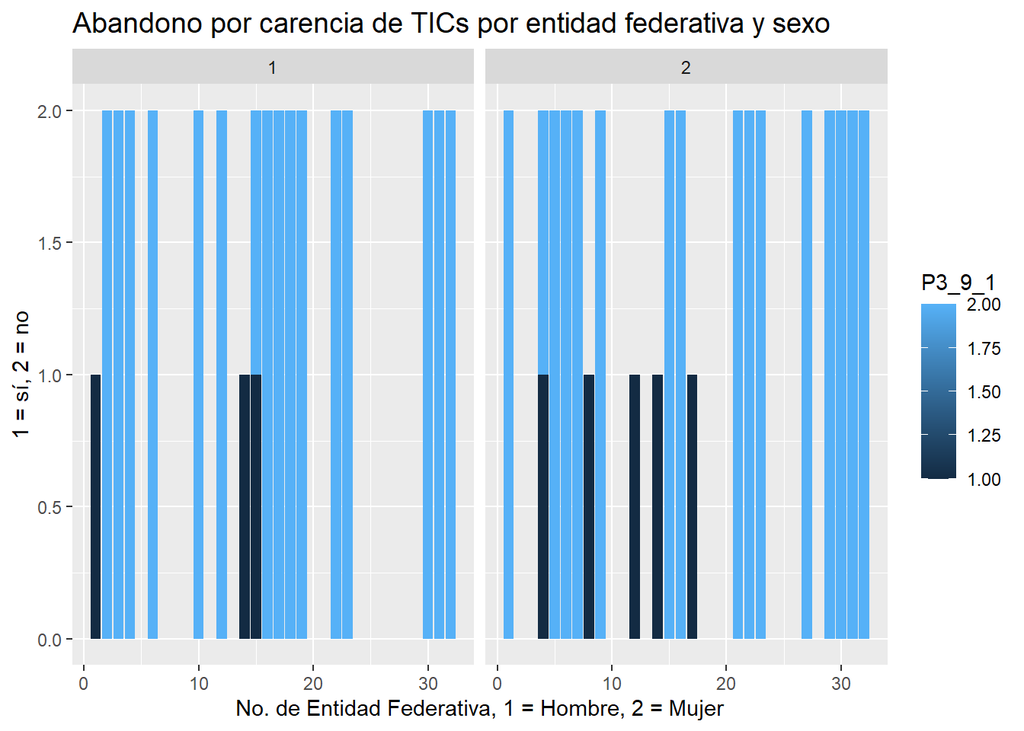

```r
# Graficamos
g2<-ggplot(bd.modulo, aes(x=ENT, y=P3_9_1, fill=P3_9_1)) +
  geom_bar(position="dodge",stat = "identity" ) +
  facet_wrap(~SEXO) +
  xlab("No. de Entidad Federativa, 1 = Hombre, 2 = Mujer") +
  ylab("1 = sí, 2 = no") +
  ggtitle("Abandono por carencia de TICs por entidad federativa y sexo" ) +
  theme(plot.title = element_text(size=14))
g2
```

En esta gráfica podemos ver en qué entidades se registró una mayoría de respuestas positivas, o bien negativas con referencia a la deserción por carencia de TICs.

### Por pérdida/reducción de ingresos familiares

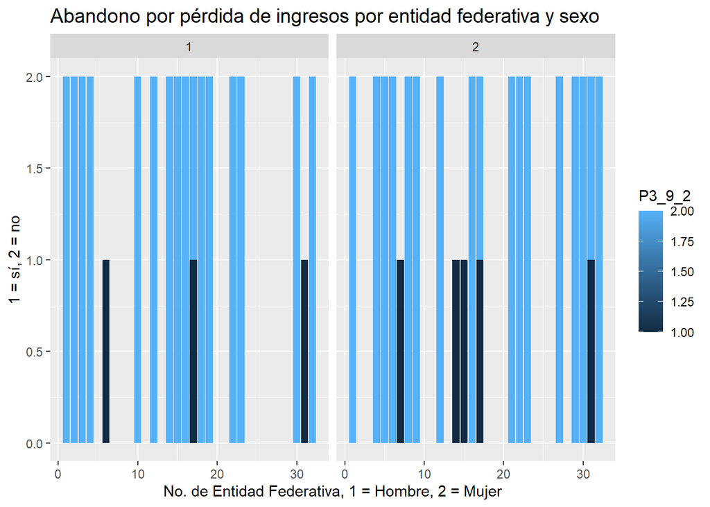

```r
# Graficamos
g3<-ggplot(bd.modulo, aes(x=ENT, y=P3_9_2, fill=P3_9_2)) +
  geom_bar(position="dodge",stat = "identity" ) +
  facet_wrap(~SEXO) +
  xlab("No. de Entidad Federativa, 1 = Hombre, 2 = Mujer") +
  ylab("1 = sí, 2 = no") +
  ggtitle("Abandono por pérdida de ingresos por entidad federativa y sexo" ) +
  theme(plot.title = element_text(size=14))
g3
```

En esta gráfica podemos ver en qué entidades se registró una mayoría de respuestas positivas, o bien negativas con referencia a la deserción por perdida de ingresos familiares.

### Por pérdida de contacto con profesores/ compañeros o por no poder hacer las tareas

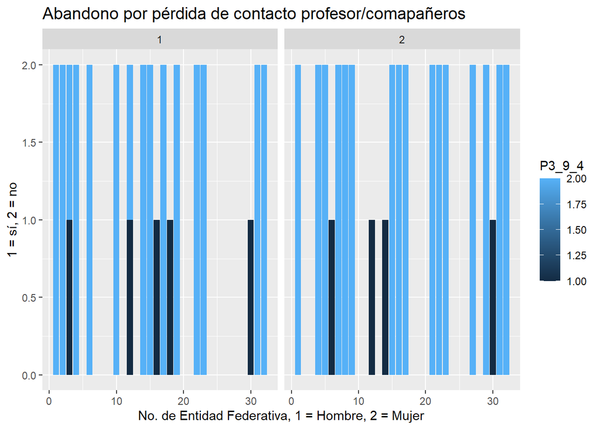

```r
# Graficamos
g4<-ggplot(bd.modulo, aes(x=ENT, y=P3_9_4, fill=P3_9_4)) +
  geom_bar(position="dodge",stat = "identity" ) +
  facet_wrap(~SEXO) +
  xlab("No. de Entidad Federativa, 1 = Hombre, 2 = Mujer") +
  ylab("1 = sí, 2 = no") +
  ggtitle("Abandono por pérdida de contacto profesor/comapañeros" ) +
  theme(plot.title = element_text(size=14))
g4
```

En esta gráfica podemos ver en qué entidades se registró una mayoría de respuestas positivas, o bien negativas referentes a la pérdida de contacto con porfesores/compañerxs o bien, por no poder hacer las tareas.

### Por familiar enfermo/fallecido de COVID 19

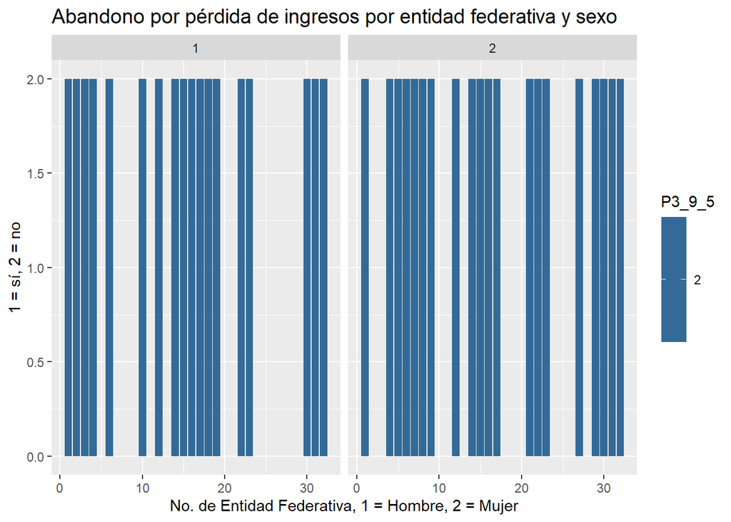

```r
# Graficamos
g5<-ggplot(bd.modulo, aes(x=ENT, y=P3_9_5, fill=P3_9_5)) +
  geom_bar(position="dodge",stat = "identity" ) +
  facet_wrap(~SEXO) +
  xlab("No. de Entidad Federativa, 1 = Hombre, 2 = Mujer") +
  ylab("1 = sí, 2 = no") +
  ggtitle("Abandono por pérdida de ingresos por entidad federativa y sexo" ) +
  theme(plot.title = element_text(size=14))
g5
```

### Por cierre definitivo del plantel educativo

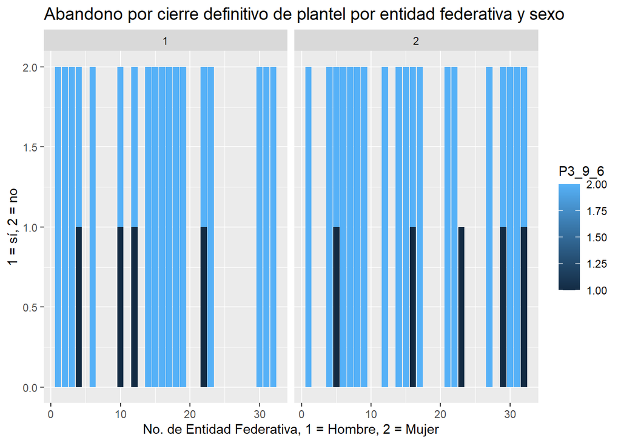

```r
# Graficamos
g6<-ggplot(bd.modulo, aes(x=ENT, y=P3_9_6, fill=P3_9_6)) +
  geom_bar(position="dodge",stat = "identity" ) +
  facet_wrap(~SEXO) +
  xlab("No. de Entidad Federativa, 1 = Hombre, 2 = Mujer") +
  ylab("1 = sí, 2 = no") +
  ggtitle("Abandono por cierre definitivo de plantel por entidad federativa y sexo" ) +
  theme(plot.title = element_text(size=14))
g6
```

En esta gráfica podemos ver en qué entidades se registró una mayoría de respuestas positivas, o bien negativas referentes al cierre definitivo de los planteles educativos.

### Por ausencia de tutor

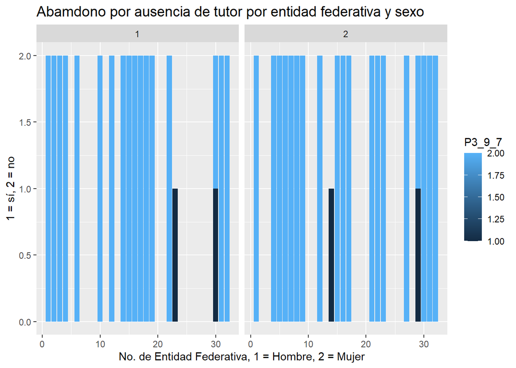

```r
# Graficamos
g7<-ggplot(bd.modulo, aes(x=ENT, y=P3_9_7, fill=P3_9_7)) +
  geom_bar(position="dodge",stat = "identity" ) +
  facet_wrap(~SEXO) +
  xlab("No. de Entidad Federativa, 1 = Hombre, 2 = Mujer") +
  ylab("1 = sí, 2 = no") +
  ggtitle("Abamdono por ausencia de tutor por entidad federativa y sexo" ) +
  theme(plot.title = element_text(size=14))
g7
```

En esta gráfica podemos ver en qué entidades se registró una mayoría de respuestas positivas, o bien negativas referentes a la ausencia del tutor.

### Por considerar poco funcionales las clases a distancia

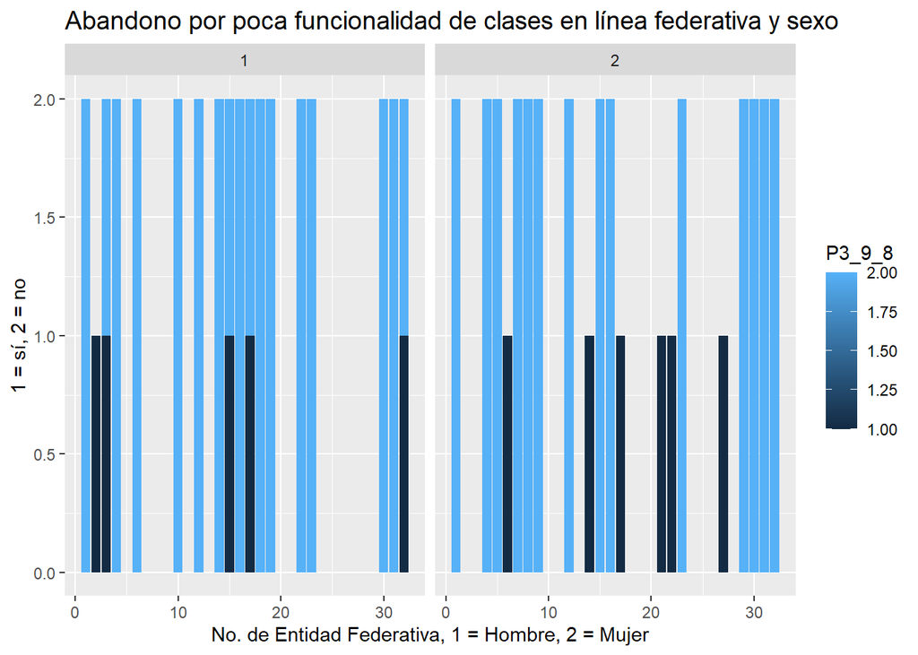

```r
# Graficamos
g8<-ggplot(bd.modulo, aes(x=ENT, y=P3_9_8, fill=P3_9_8)) +
  geom_bar(position="dodge",stat = "identity" ) +
  facet_wrap(~SEXO) +
  xlab("No. de Entidad Federativa, 1 = Hombre, 2 = Mujer") +
  ylab("1 = sí, 2 = no") +
  ggtitle("Abandono por poca funcionalidad de clases en línea federativa y sexo" ) +
  theme(plot.title = element_text(size=14))
g8
```

En esta gráfica podemos ver en qué entidades se registró una mayoría de respuestas positivas, o bien negativas referentes a considerar poco funcionales las clases a distancia.

## Razones para no cursar el presente ciclo escolar

### Por COVID 19

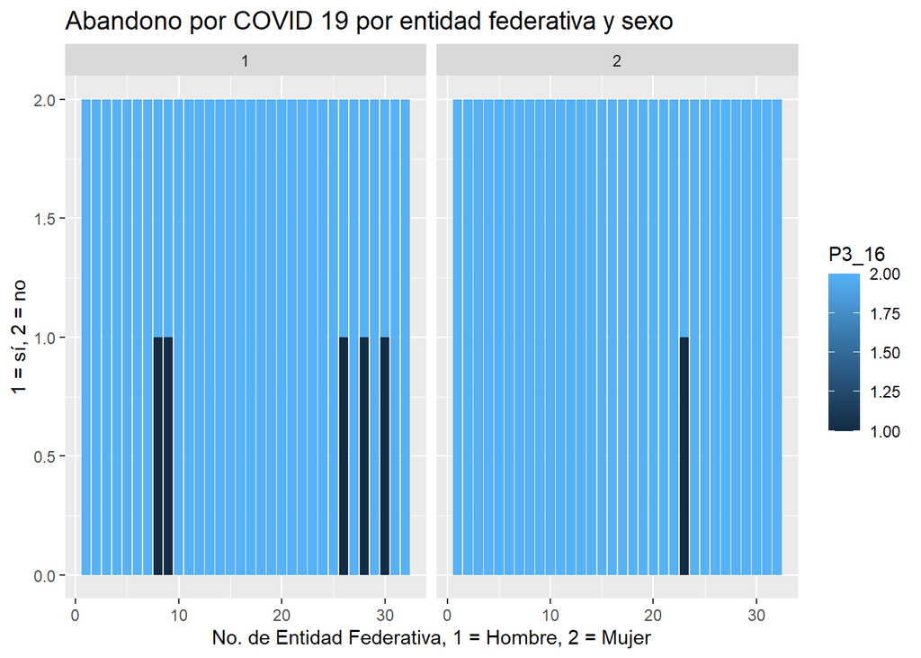

```r
# Cargamos las librerías
library(ggplot2)
library(viridisLite)
library(hrbrthemes)

# Graficamos
g21<-ggplot(bd.modulo, aes(x=ENT, y=P3_16, fill=P3_16)) +
  geom_bar(position="dodge",stat = "identity" ) +
  facet_wrap(~SEXO) +
  xlab("No. de Entidad Federativa, 1 = Hombre, 2 = Mujer") +
  ylab("1 = sí, 2 = no") +
  ggtitle("Abandono por COVID 19 por entidad federativa y sexo" ) +
  theme(plot.title = element_text(size=14))
g21
```

Ahora vamos a analizar los resultados referentes a la pregunta ‘’Razones para no cursar el presente ciclo escolar’’. Se graficará y analizará cada variable.

### Por carencia de TICs

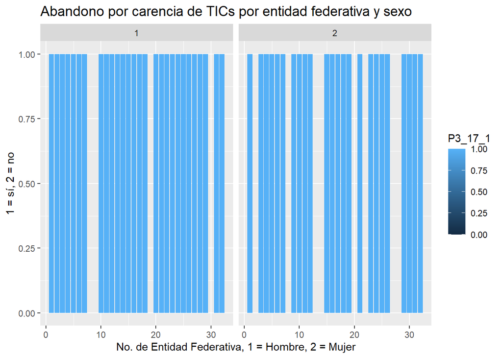

```r
# Graficamos
g22<-ggplot(bd.modulo, aes(x=ENT, y=P3_17_1, fill=P3_17_1)) +
  geom_bar(position="dodge",stat = "identity" ) +
  facet_wrap(~SEXO) +
  xlab("No. de Entidad Federativa, 1 = Hombre, 2 = Mujer") +
  ylab("1 = sí, 2 = no") +
  ggtitle("Abandono por carencia de TICs por entidad federativa y sexo" ) +
  theme(plot.title = element_text(size=14))
g22
```

En esta gráfica podemos ver en qué entidades se registró una mayoría de respuestas positivas, o bien negativas referentes a no cursar el presente ciclo escolar por la carencia de TICs en el hogar.

### Por pérdida/reducción de ingresos familiares

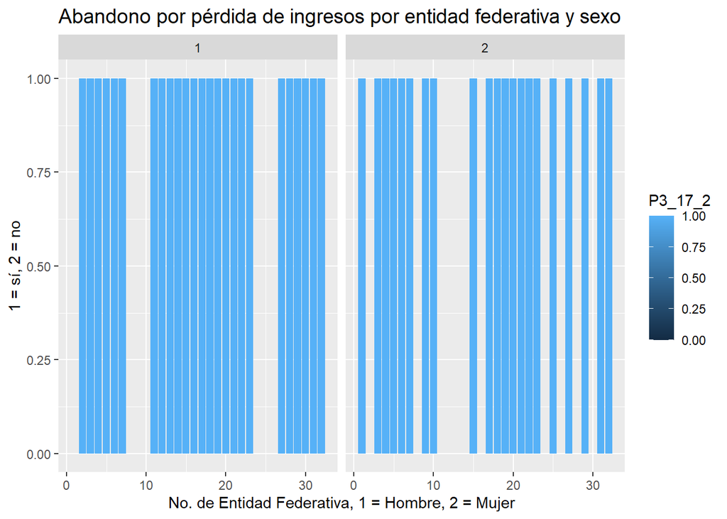

```r
# Graficamos
g23<-ggplot(bd.modulo, aes(x=ENT, y=P3_17_2, fill=P3_17_2)) +
  geom_bar(position="dodge",stat = "identity" ) +
  facet_wrap(~SEXO) +
  xlab("No. de Entidad Federativa, 1 = Hombre, 2 = Mujer") +
  ylab("1 = sí, 2 = no") +
  ggtitle("Abandono por pérdida de ingresos por entidad federativa y sexo" ) +
  theme(plot.title = element_text(size=14))
g23
```

En esta gráfica podemos ver en qué entidades se registró una mayoría de respuestas positivas, o bien negativas referentes a no cursar el presente ciclo escolar por la pérdida o reducción de ingresos familiares.

### Por familiar enfermo/fallecido de COVID 19

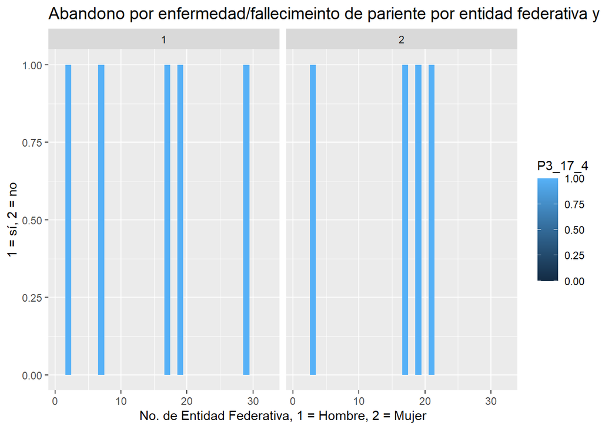

```r
# Graficamos
g24<-ggplot(bd.modulo, aes(x=ENT, y=P3_17_4, fill=P3_17_4)) +
  geom_bar(position="dodge",stat = "identity" ) +
  facet_wrap(~SEXO) +
  xlab("No. de Entidad Federativa, 1 = Hombre, 2 = Mujer") +
  ylab("1 = sí, 2 = no") +
  ggtitle("Abandono por enfermedad/fallecimeinto de pariente por entidad federativa y sexo" ) +
  theme(plot.title = element_text(size=14))
g24
```

En esta gráfica podemos ver en qué entidades se registró una mayoría de respuestas positivas, o bien negativas referentes a no cursar el presente ciclo escolar por el contagio o fallecimiento de algún familiar por COVID-19.

### Por cierre definitivo del plantel educativo

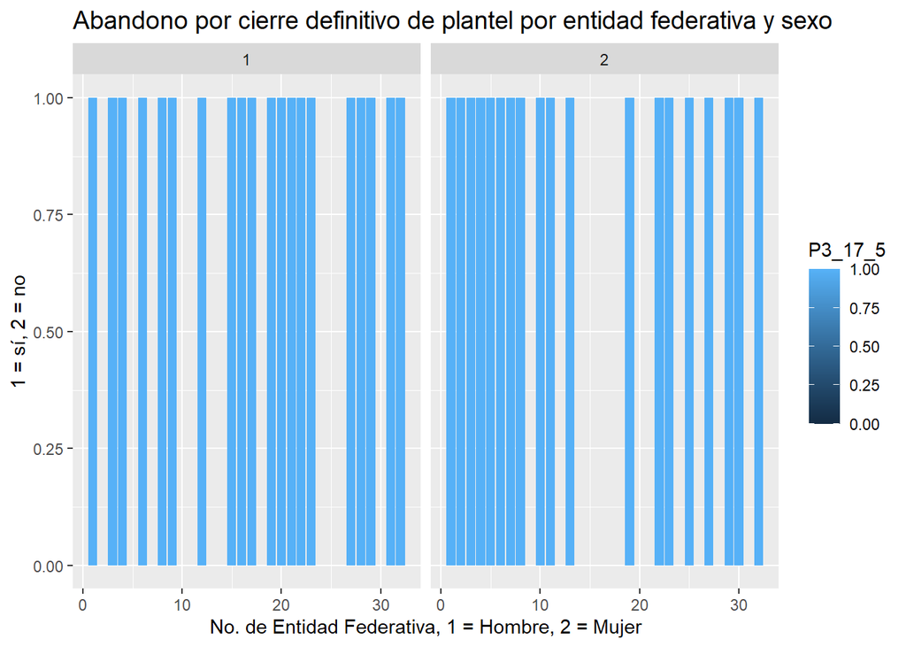

```r
# Graficamos
g25<-ggplot(bd.modulo, aes(x=ENT, y=P3_17_5, fill=P3_17_5)) +
  geom_bar(position="dodge",stat = "identity" ) +
  facet_wrap(~SEXO) +
  xlab("No. de Entidad Federativa, 1 = Hombre, 2 = Mujer") +
  ylab("1 = sí, 2 = no") +
  ggtitle("Abandono por cierre definitivo de plantel por entidad federativa y sexo" ) +
  theme(plot.title = element_text(size=14))
g25
```

En esta gráfica podemos ver en qué entidades se registró una mayoría de respuestas positivas, o bien negativas referentes a no cursar el presente ciclo escolar por el cierre definitivo del plantel educativo.

### Por ausencia de tutor

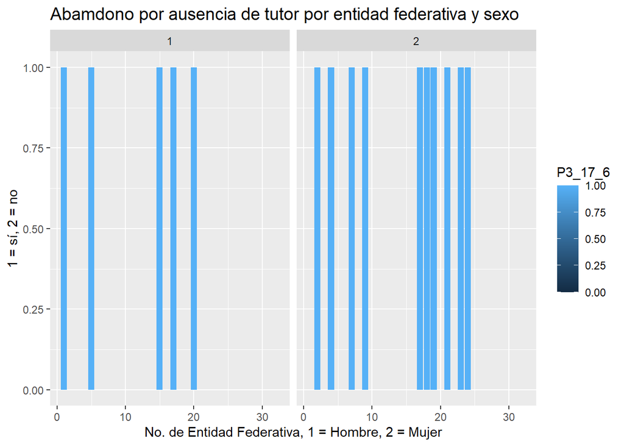

```r
# Graficamos
g26<-ggplot(bd.modulo, aes(x=ENT, y=P3_17_6, fill=P3_17_6)) +
  geom_bar(position="dodge",stat = "identity" ) +
  facet_wrap(~SEXO) +
  xlab("No. de Entidad Federativa, 1 = Hombre, 2 = Mujer") +
  ylab("1 = sí, 2 = no") +
  ggtitle("Abamdono por ausencia de tutor por entidad federativa y sexo" ) +
  theme(plot.title = element_text(size=14))
g26
```

En esta gráfica podemos ver en qué entidades se registró una mayoría de respuestas positivas, o bien negativas referentes a no cursar el presente ciclo escolar por la ausencia del tutor/tutora.

### Por considerar poco funcionales las clases a distancia

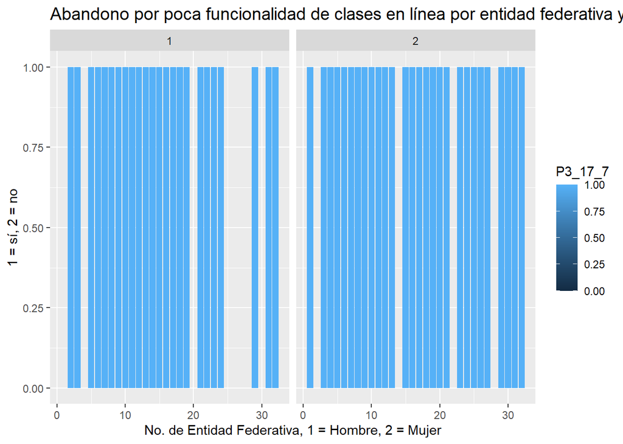

```r
# Graficamos
g27<-ggplot(bd.modulo, aes(x=ENT, y=P3_17_7, fill=P3_17_7)) +
  geom_bar(position="dodge",stat = "identity" ) +
  facet_wrap(~SEXO) +
  xlab("No. de Entidad Federativa, 1 = Hombre, 2 = Mujer") +
  ylab("1 = sí, 2 = no") +
  ggtitle("Abandono por poca funcionalidad de clases en línea por entidad federativa y sexo" ) +
  theme(plot.title = element_text(size=14))
g27
```

En esta gráfica podemos ver en qué entidades se registró una mayoría de respuestas positivas, o bien negativas referentes a no cursar el presente ciclo escolar por considerar poco funcionales las clases a distancia.

## Razones para cambiar de escuela

### Por cambio de residencia

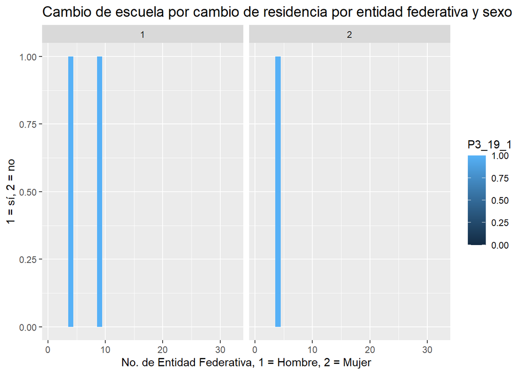

```r
# Graficamos
g31<-ggplot(bd.modulo, aes(x=ENT, y=P3_19_1, fill=P3_19_1)) +
  geom_bar(position="dodge",stat = "identity" ) +
  facet_wrap(~SEXO) +
  xlab("No. de Entidad Federativa, 1 = Hombre, 2 = Mujer") +
  ylab("1 = sí, 2 = no") +
  ggtitle("Cambio de escuela por cambio de residencia por entidad federativa y sexo" ) +
  theme(plot.title = element_text(size=14))
g31
```

### Por cambio de nivel educativo

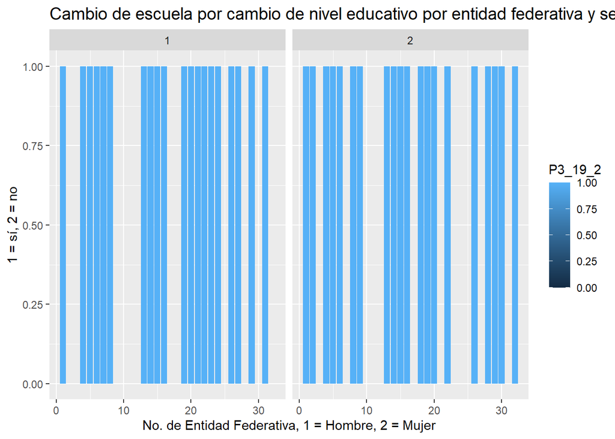

```r
# Graficamos
g32<-ggplot(bd.modulo, aes(x=ENT, y=P3_19_2, fill=P3_19_2)) +
  geom_bar(position="dodge",stat = "identity" ) +
  facet_wrap(~SEXO) +
  xlab("No. de Entidad Federativa, 1 = Hombre, 2 = Mujer") +
  ylab("1 = sí, 2 = no") +
  ggtitle("Cambio de escuela por cambio de nivel educativo por entidad federativa y sexo" ) +
  theme(plot.title = element_text(size=14))
g32
```

### Por cierre definitivo del plantel por COVID 19

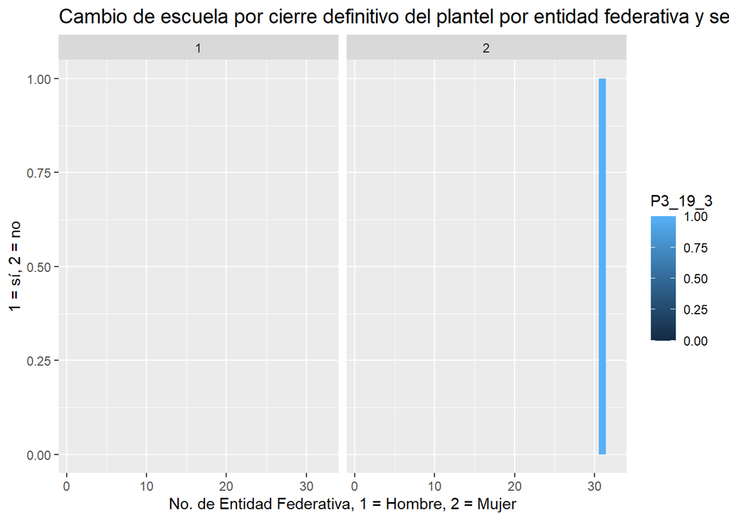

```r
# Graficamos
g33<-ggplot(bd.modulo, aes(x=ENT, y=P3_19_3, fill=P3_19_3)) +
  geom_bar(position="dodge",stat = "identity" ) +
  facet_wrap(~SEXO) +
  xlab("No. de Entidad Federativa, 1 = Hombre, 2 = Mujer") +
  ylab("1 = sí, 2 = no") +
  ggtitle("Cambio de escuela por cierre definitivo del plantel por entidad federativa y sexo" ) +
  theme(plot.title = element_text(size=14))
g33
```

### Por colegiatura

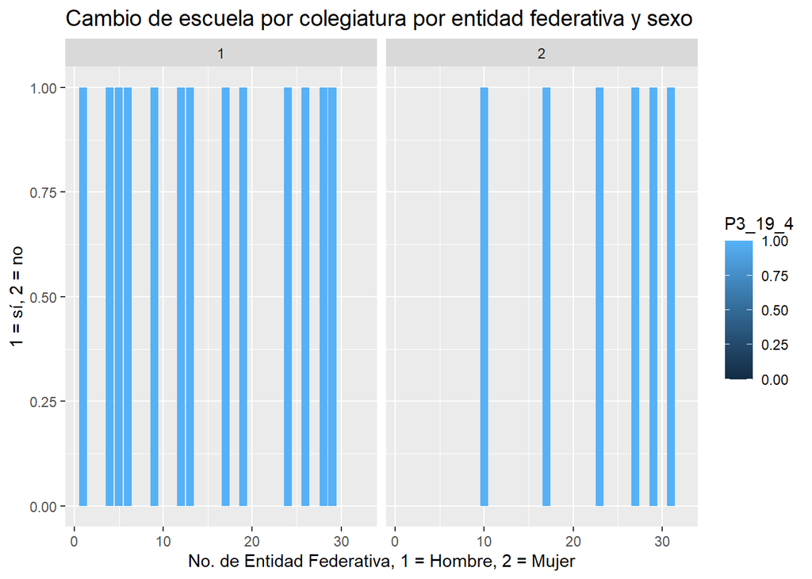

```r
# Graficamos
g34<-ggplot(bd.modulo, aes(x=ENT, y=P3_19_4, fill=P3_19_4)) +
  geom_bar(position="dodge",stat = "identity" ) +
  facet_wrap(~SEXO) +
  xlab("No. de Entidad Federativa, 1 = Hombre, 2 = Mujer") +
  ylab("1 = sí, 2 = no") +
  ggtitle("Cambio de escuela por colegiatura por entidad federativa y sexo" ) +
  theme(plot.title = element_text(size=14))
g34
```

### Por mala gestión de clases virtuales por parte de la institución educativa

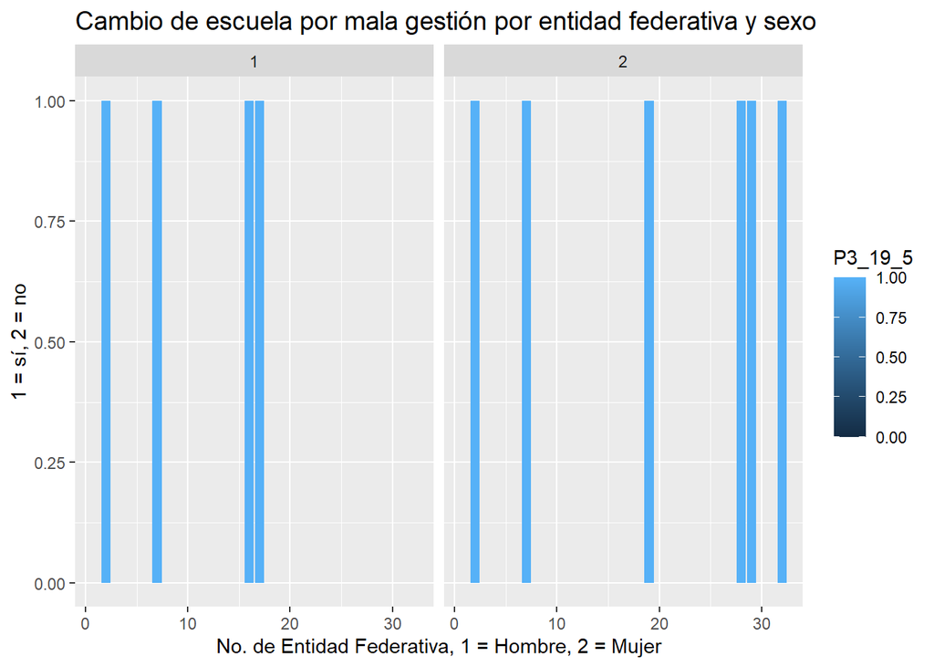

```r
# Graficamos
g35<-ggplot(bd.modulo, aes(x=ENT, y=P3_19_5, fill=P3_19_5)) +
  geom_bar(position="dodge",stat = "identity" ) +
  facet_wrap(~SEXO) +
  xlab("No. de Entidad Federativa, 1 = Hombre, 2 = Mujer") +
  ylab("1 = sí, 2 = no") +
  ggtitle("Cambio de escuela por mala gestión por entidad federativa y sexo" ) +
  theme(plot.title = element_text(size=14))
g35
```

### Por otros motivos

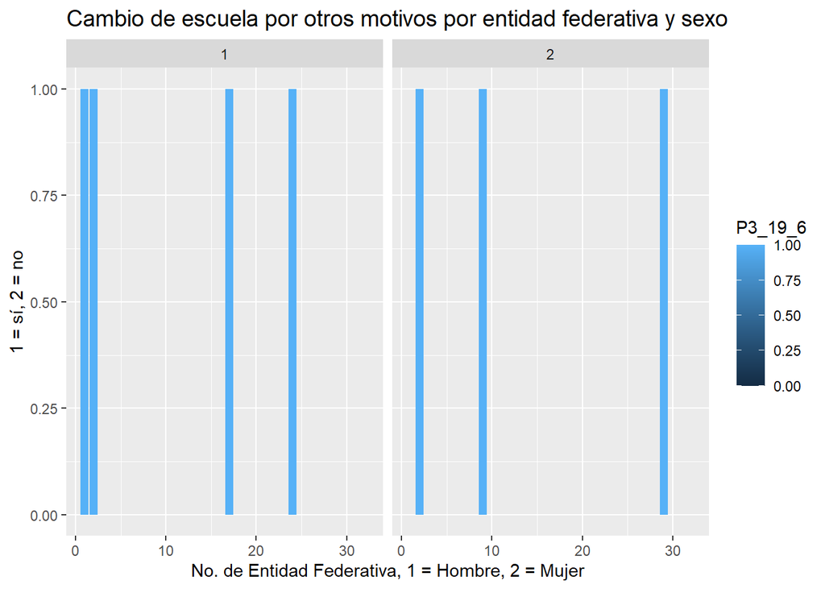

```r
# Graficamos
g36<-ggplot(bd.modulo, aes(x=ENT, y=P3_19_6, fill=P3_19_6)) +
  geom_bar(position="dodge",stat = "identity" ) +
  facet_wrap(~SEXO) +
  xlab("No. de Entidad Federativa, 1 = Hombre, 2 = Mujer") +
  ylab("1 = sí, 2 = no") +
  ggtitle("Cambio de escuela por otros motivos por entidad federativa y sexo" ) +
  theme(plot.title = element_text(size=14))
g36
```

### Porque no le gustaba la escuela

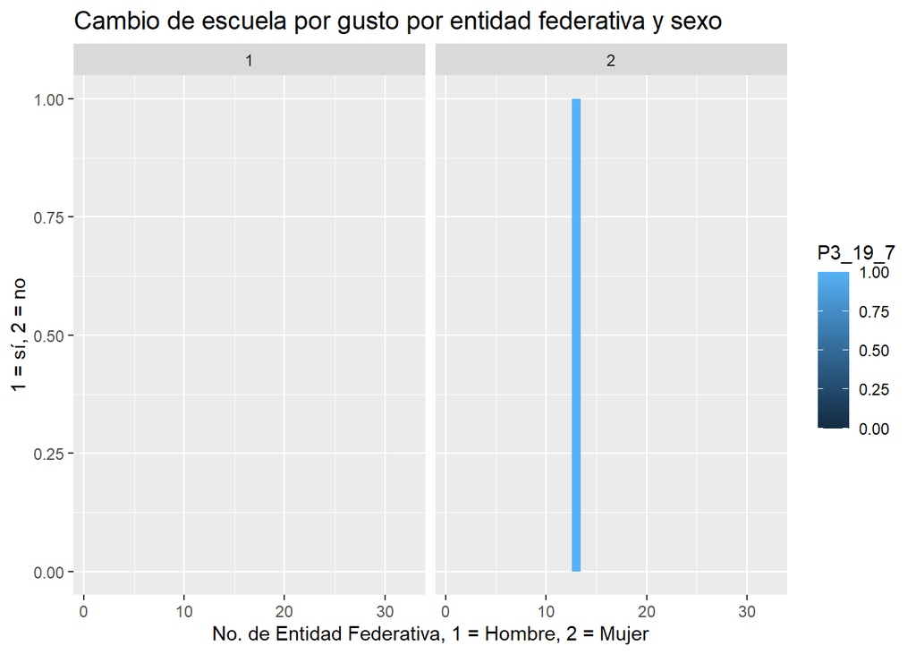

```r
# Graficamos
g37<-ggplot(bd.modulo, aes(x=ENT, y=P3_19_7, fill=P3_19_7)) +
  geom_bar(position="dodge",stat = "identity" ) +
  facet_wrap(~SEXO) +
  xlab("No. de Entidad Federativa, 1 = Hombre, 2 = Mujer") +
  ylab("1 = sí, 2 = no") +
  ggtitle("Cambio de escuela por gusto por entidad federativa y sexo" ) +
  theme(plot.title = element_text(size=14))
g37
```

## TICs

### Uso de TICs durante el ciclo escolar pasado

### Uso de TICs durante el presente año escolar